# toa_influx

### Introduction

Author: Jake Goh

Date: 4th December 2025

Description: This notebook documents the process to do exploratory Data Analysis on the ERA5-Land and ERA5 sample datasets downloaded. There is a need to productionize this in the future with the full dataset

```python
%load_ext autoreload
%autoreload 2
```

```python
import geopandas as gpd
import matplotlib.pyplot as plt
import logging
import xarray as xr
import os
import re
import numpy as np
import sys
import matplotlib.colors as mcolors
import pandas as pd
import cartopy.crs as ccrs
import cartopy.feature as cfeature
import calendar
import matplotlib.dates as mdates
import pytz
from datetime import datetime, timedelta


# Adds the parent folder to Python's import path so we can import modules from it
directory_path = os.path.abspath(os.path.join('..')) # Go up one level
if directory_path not in sys.path:
        sys.path.append(directory_path)
from src import toa_influx_functions as tf


logging.basicConfig(level=logging.INFO)
```

### Setting up the datasets for analysis

This includes processing the data using the functions in toa_influx_functions

```python
# Reading the ERA5_Land dataset
era5_land_ds = xr.open_dataset("..\data\malaysia_era5_land_extracted\era5_land_malaysia_2022_year.nc", engine="netcdf4")
```

```python
#Calculate the TOA Irradiance/Influx
era5_land_ds = tf.convert_to_radians(era5_land_ds)
era5_land_ds = tf.calc_day_of_year(era5_land_ds)
era5_land_ds = tf.calc_eccentricty_correlation_factor(era5_land_ds)
era5_land_ds = tf.calc_hour_angle(era5_land_ds)
era5_land_ds = tf.calc_solar_declination_angle(era5_land_ds)
era5_land_ds = tf.calc_solar_zenith_angle(era5_land_ds)

#This will add the instantaneous/incident TOA influx at that timestamp. So it is in W/m^2.
ra5_land_ds = tf.calc_toa_incident_shortwave(era5_land_ds)

#To get the total influx in the hour, we multiply it by 3600 seconds (1 hour). Result is in J/m^2.
era5_land_ds["toa_influx_hourly"] = era5_land_ds["toa_influx"] * 3600
```

```python
#Reading the prepared dataset
era5_ds = xr.open_dataset("..\data\malaysia_era5_extracted\era5_malaysia_2022_year.nc", engine="netcdf4")
```

```python
#For analysis purposes.
#Sum the total hourly influx by month and calculate the average monthly total influx over the year.
# Units: J/m^2 per month
total_influx = era5_land_ds["toa_influx_hourly"].groupby("valid_time.month").sum("valid_time")
mean_monthly_total = total_influx.mean("month")
```

```python
#For analysis purposes. Sams as code block above but using ERA5 dataset
total_influx_era5 = era5_ds["tisr"].groupby("valid_time.month").sum("valid_time")
mean_monthly_total_era5 = total_influx_era5.mean("month")
```

### EDA: how does the resolution for both datasets compare?

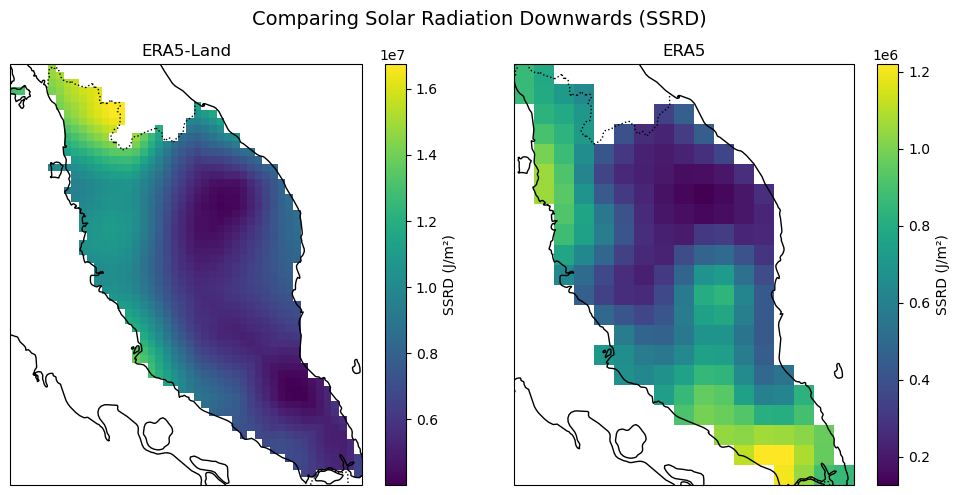

```python
#Era5 vs Era5land resolution

#This block of code is just to clip the data to Peninsular Malaysia's land boundary so there is no values outside of it.

malaysia = gpd.read_file('gadm41_MYS_shp/gadm41_MYS_1.shp')

east_malaysia_states = ["Labuan", "Sabah", "Sarawak"]
peninsular_malaysia = malaysia[~malaysia["NAME_1"].isin(east_malaysia_states)]

# Make sure its coordinate reference system (CRS) matches the dataset (ERA5-Land is in EPSG:4326).
peninsular_malaysia = peninsular_malaysia.to_crs(epsg=4326)

# Create map figure
fig, axes = plt.subplots(1, 2, figsize=(10, 5),
                         subplot_kw={'projection': ccrs.PlateCarree()})
# Assigning CRS to the data
era5land_plot_data = era5_land_ds["ssrd"].isel(valid_time = 0).rio.write_crs("EPSG:4326")

#Clipping based on the mask
era5land_plot_data = era5land_plot_data.rio.clip(peninsular_malaysia.geometry, peninsular_malaysia.crs)

#Assigning CRS to the data
era5_ds_plot_data = era5_ds["ssrd"].isel(valid_time = 2).rio.write_crs("EPSG:4326")

#Clipping based on the mask
era5_ds_plot_data = era5_ds_plot_data.rio.clip(peninsular_malaysia.geometry, peninsular_malaysia.crs)


for i, ax in enumerate(axes):
        if i == 0:
                era5land_plot_data.plot(
                        x="longitude", y="latitude",
                        ax=ax, transform=ccrs.PlateCarree(),
                        cbar_kwargs={"label": "SSRD (J/m²)"})

                ax.coastlines(resolution="10m")
                ax.add_feature(cfeature.BORDERS, linestyle=":")
                ax.set_title("ERA5-Land")
        else:
                era5_ds_plot_data.plot(
                        x="longitude", y="latitude",
                        ax=ax, transform=ccrs.PlateCarree(),
                        cbar_kwargs={"label": "SSRD (J/m²)"})

                ax.coastlines(resolution="10m")
                ax.add_feature(cfeature.BORDERS, linestyle=":")
                ax.set_title("ERA5")


fig.suptitle("Comparing Solar Radiation Downwards (SSRD)", fontsize = 14)
plt.tight_layout()
plt.show()
```

### Validation and Sanity Checks

Here are the list of EDA and checks that I wanted to do to test the functions that I implemented in src/toa_functions.py

##### Surface checks

1. Plot the calculated toa_influx on the map. It should look physically reasonable, such as no weird banding, missing values, negative values.

**Example of wrong would be like below**. Clearly something is wrong here since there are negative values and the TOA influx is similar across the latitude.

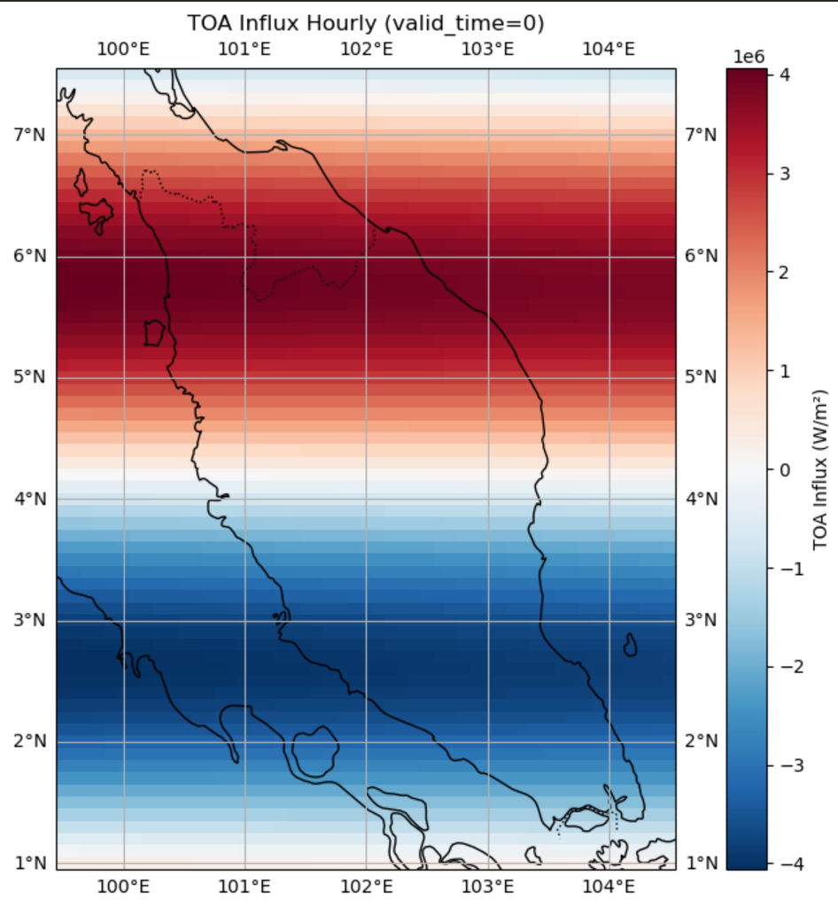

##### Sanity Check

1. Does the spatial and temporal aspects make sense? Do we see irradiance growing in the morning, peaking at noon, declining in the afternoon and none at night?

##### Comparison check.

1. On aggregate, the values of the toa_influx from both datasets must agree with each other
2. For a chosen latitude and longitude, the hourly toa_influx in ERA5_Land should match the TISR in ERA5.

##### Statistical checks

1. Use statistical metrics such as nrmse, nmae, correlation, etc to compare the predicted value with the baseline for each grid cell across the year.

##### Unit testing

1. Test each function and check the resultant value to see if it matches logical/physical values. This is already implemented in the unit tests files.
2. Select a particular latitude, longitude and time and see if it matches online resources:

### Surface Level Check

Plotted the calculated toa_influx on the map. This looks believable. There are values throughout the region, and there is no banding issues as observed like above. There is also a smooth transition between each cell in the region.

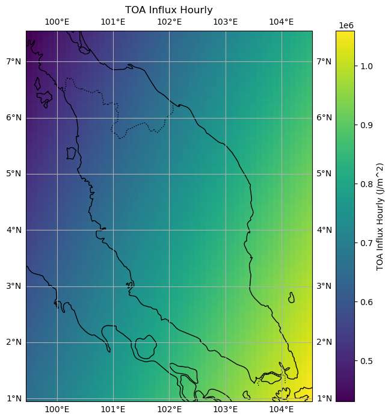

```python
#Note, we can also do the same clipping to Malaysia's region as the first EDA plot that we did.
#I kept it like this to show how it would look like without clipping.

toa_influx_hourly = era5_land_ds["toa_influx_hourly"]
fig = plt.figure(figsize=(10, 8))
ax = fig.add_subplot(1, 1, 1, projection=ccrs.PlateCarree()) # Or other projection
toa_influx_hourly.isel(valid_time=0).plot(ax=ax, transform=ccrs.PlateCarree(), cbar_kwargs={'label': 'TOA Influx Hourly (J/m^2)'})
ax.coastlines()
ax.add_feature(cfeature.BORDERS, linestyle=':')
ax.gridlines(draw_labels=True)
ax.set_title("TOA Influx Hourly")
plt.show()
```

### Sanity Check

Plotted the TOA influx on a map to show spatial correctness. I also plotted based on different timestamp to see if it varies based on what I was expecting.

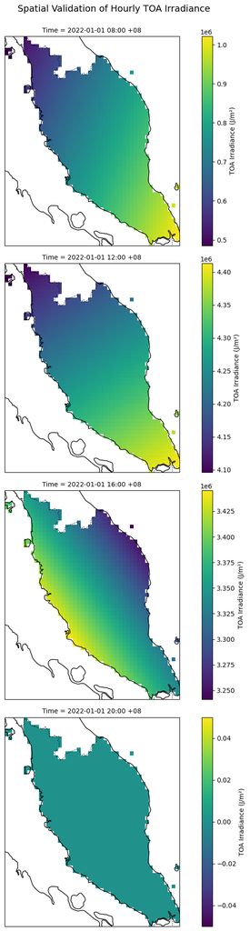

```python
#Let's only keep the values within Malaysia
#Reference: https://automating-gis-processes.github.io/CSC/notebooks/L2/geopandas-basics.html

#Clipping the results
malaysia = gpd.read_file('gadm41_MYS_shp/gadm41_MYS_1.shp')

east_malaysia_states = ["Labuan", "Sabah", "Sarawak"]
peninsular_malaysia = malaysia[~malaysia["NAME_1"].isin(east_malaysia_states)]

# Make sure its coordinate reference system (CRS) matches the datasets
peninsular_malaysia = peninsular_malaysia.to_crs(epsg=4326)

# Choose time indices to visualize
time_indices = [0, 4, 8, 12]

# Create map figure
fig, axes = plt.subplots(len(time_indices), 1, figsize=(10, 20),
                         subplot_kw={'projection': ccrs.PlateCarree()})

toa_influx_hourly = era5_land_ds["toa_influx_hourly"]
#Assigning CRS to the data
toa_influx_hourly = toa_influx_hourly.rio.write_crs("EPSG:4326")
#Clipping based on the mask
toa_influx_hourly = toa_influx_hourly.rio.clip(peninsular_malaysia.geometry, peninsular_malaysia.crs)


#Unused code: The norm is not suitable because the wide range of values in the day and I still want to show the variation in the same time in different locations
#norm = mcolors.SymLogNorm(linthresh=1e5, linscale=1.0, vmin=0, vmax=5e7)
#norm = mcolors.SymLogNorm(linthresh=100, linscale=0.5, vmin=0, vmax=5e6)
# vmin = 0
# vmax = 3.5e6

for i, ax in enumerate(axes):
    idx = time_indices[i]
    time_value = toa_influx_hourly.valid_time.isel(valid_time=idx).values


    (toa_influx_hourly.isel(valid_time=idx)).plot(
        x="longitude", y="latitude",
        ax=ax, transform=ccrs.PlateCarree(),
        #norm = norm,
        #vmin = vmin,  vmax= vmax,
        cbar_kwargs={"label": "TOA Irradiance (J/m²)"}
    )

    ax.coastlines(resolution="10m")
    ax.add_feature(cfeature.BORDERS, linestyle=":")

    # Convert UTC → Malaysia time (UTC+8)
    time_label = (
        pd.to_datetime(time_value)
        .tz_localize("UTC")
        .tz_convert("Asia/Kuala_Lumpur")
    )

    # Format to readable string
    time_str = time_label.strftime("%Y-%m-%d %H:%M %Z")
    ax.set_title(f"Time = {time_str}", fontsize = 10)

fig.suptitle("Spatial Validation of Hourly TOA Irradiance", fontsize = 14, x = 0.65, y = 1.0)
plt.tight_layout()
plt.show()
```

I was also curious to see which regions have more irradiance in different periods of the year.

And October to March 2022 have more irradiance in the southern regions.

This trend seems to coincide with the monsoon periods in Malaysia. But this is Top-of-atmosphere irradiance which is unaffected by monsoon wind patterns below the atmosphere. This can be simply be explained by the seasonal movement of the sun and not by the monsoon season.

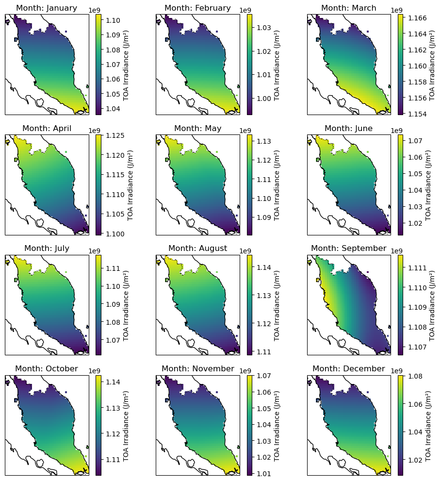

```python
malaysia = gpd.read_file('gadm41_MYS_shp/gadm41_MYS_1.shp')

east_malaysia_states = ["Labuan", "Sabah", "Sarawak"]
peninsular_malaysia = malaysia[~malaysia["NAME_1"].isin(east_malaysia_states)]

# Make sure its coordinate reference system (CRS) matches the datasets.
peninsular_malaysia = peninsular_malaysia.to_crs(epsg=4326)


# Create map figure
fig, axes = plt.subplots(4, 3, figsize=(10, 10),
                         subplot_kw={'projection': ccrs.PlateCarree()})


monthly_mean_data = total_influx
#Assigning CRS to the data
monthly_mean_data = monthly_mean_data.rio.write_crs("EPSG:4326")
#Clipping based on the mask
monthly_mean_data = monthly_mean_data.rio.clip(peninsular_malaysia.geometry, peninsular_malaysia.crs)

axes = axes.flatten()

for i, ax in enumerate(axes):

    (monthly_mean_data.isel(month=i)).plot(
        x="longitude", y="latitude",
        ax=ax, transform=ccrs.PlateCarree(),
        #norm = norm,
        #vmin = 0,  vmax= vmax,
        cbar_kwargs={"label": "TOA Irradiance (J/m²)"}
    )

    ax.coastlines(resolution="10m")
    ax.add_feature(cfeature.BORDERS, linestyle=":")

    # Format to readable string
    month_str = calendar.month_name[i+1]
    ax.set_title(f"Month: {month_str}")

plt.tight_layout()
plt.show()
```

### Comparison check 1

1. On aggregate, the values of the toa_influx from both datasets must agree with each other

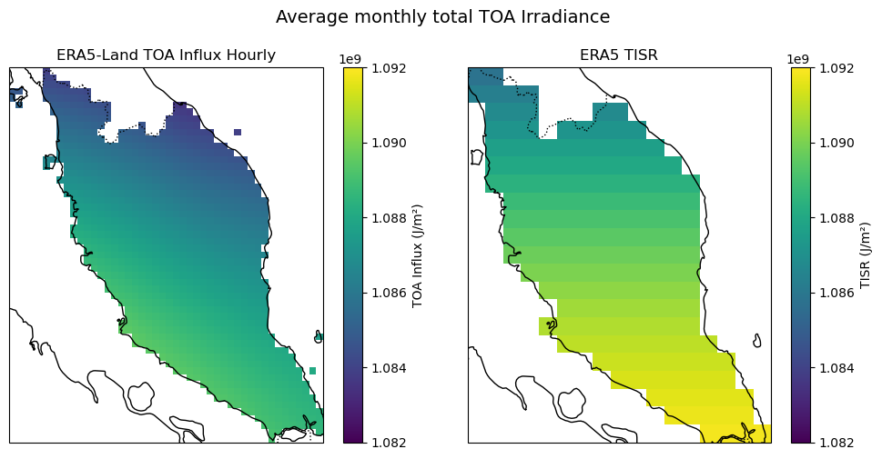

```python
malaysia = gpd.read_file('gadm41_MYS_shp/gadm41_MYS_1.shp')

east_malaysia_states = ["Labuan", "Sabah", "Sarawak"]
peninsular_malaysia = malaysia[~malaysia["NAME_1"].isin(east_malaysia_states)]


# Make sure its coordinate reference system (CRS) matches the datasets
peninsular_malaysia = peninsular_malaysia.to_crs(epsg=4326)


# Create map figure
fig, axes = plt.subplots(1, 2, figsize=(10, 5),
                         subplot_kw={'projection': ccrs.PlateCarree()})
#Assigning CRS to the data
mean_monthly_total = mean_monthly_total.rio.write_crs("EPSG:4326")
#Clipping based on the mask
mean_monthly_total = mean_monthly_total.rio.clip(peninsular_malaysia.geometry, peninsular_malaysia.crs)


#Assigning CRS to the data
mean_monthly_total_era5 = mean_monthly_total_era5.rio.write_crs("EPSG:4326")
#Clipping based on the mask
mean_monthly_total_era5 = mean_monthly_total_era5.rio.clip(peninsular_malaysia.geometry, peninsular_malaysia.crs)


vmin = 1.082e9
vmax = 1.092e9
for i, ax in enumerate(axes):

        if i == 0:

                mean_monthly_total.plot(
                        x="longitude", y="latitude",
                        ax=ax, transform=ccrs.PlateCarree(),
                        #norm = norm,
                        vmin = vmin,  vmax= vmax,
                        cbar_kwargs={"label": "TOA Influx (J/m²)"})

                ax.coastlines(resolution="10m")
                ax.add_feature(cfeature.BORDERS, linestyle=":")
                ax.set_title("ERA5-Land TOA Influx Hourly")

        else:
                mean_monthly_total_era5.plot(
                        x="longitude", y="latitude",
                        ax=ax, transform=ccrs.PlateCarree(),
                        #norm = norm,
                        vmin = vmin,  vmax= vmax,
                        cbar_kwargs={"label": "TISR (J/m²)"})

                ax.coastlines(resolution="10m")
                ax.add_feature(cfeature.BORDERS, linestyle=":")
                ax.set_title("ERA5 TISR")

fig.suptitle("Average monthly total TOA Irradiance", fontsize = 14, x = 0.5, y = 1.0)
plt.tight_layout()
plt.show()
```

The plots above show the average monthy total irradiance for both datasets. The difference in both is quite small, by keeping in mind this is the **total accumulated hourly influx**, so even small hourly differences can compound. Overall, it shows similar spatil patterns.

### Comparison check 2

For a chosen latitude and longitude, the hourly toa_influx in ERA5_Land should match the TISR in ERA5.

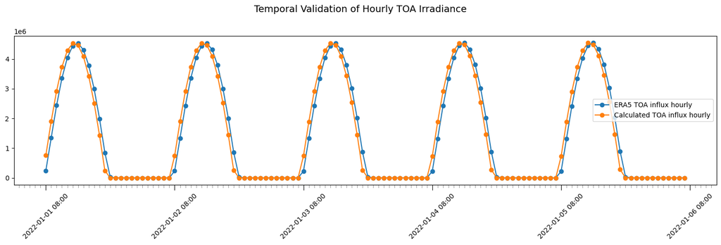

```python
lat = 3.12
lon = 101.58

# extract both series at same point
toa_calc_point = era5_land_ds["toa_influx_hourly"].sel(latitude=lat, longitude=lon, method="nearest")
tisr_point     = era5_ds["tisr"].sel(latitude=lat, longitude=lon, method="nearest")

# restrict to first ~240 hours (~10 days)
toa_calc_slice = toa_calc_point.isel(valid_time=slice(0,24*5))
tisr_slice     = tisr_point.isel(valid_time=slice(0,24*5))

# create figure
fig, ax = plt.subplots(figsize=(15, 5))

ax.plot(tisr_slice.valid_time, tisr_slice, label="ERA5 TOA influx hourly", marker="o")
ax.plot(toa_calc_slice.valid_time, toa_calc_slice, label="Calculated TOA influx hourly", marker="o")


# Timezone objects
utc = pytz.UTC
kl = pytz.timezone("Asia/Kuala_Lumpur")

def utc_to_kl_formatter(x, pos):
    """Format ticks: convert UTC → KL, then display."""
    dt_utc = mdates.num2date(x).replace(tzinfo=utc)
    dt_kl = dt_utc.astimezone(kl)
    return dt_kl.strftime('%Y-%m-%d %H:%M')

ax.xaxis.set_major_locator(mdates.DayLocator())
ax.xaxis.set_major_formatter(utc_to_kl_formatter)

# Minor ticks = hourly
ax.xaxis.set_minor_locator(mdates.HourLocator())

# Make the minor ticks more visible
ax.tick_params(axis='x', which='minor', length=4, color='gray')
ax.tick_params(axis='x', which='major', length=8)


fig.suptitle("Temporal Validation of Hourly TOA Irradiance ", fontsize = 14, x = 0.5, y = 1.0)
plt.xticks(rotation=45)
plt.legend()
plt.tight_layout()
plt.show()
```

The graph look like this is because the TOA influx is for the next hour.

The ERA5 TISR is the accummulation of the total influx for the past hour. So TISR at: 8am is the total irradiation from 7am to 8am.

The ERA5_Land computation is for the next hour. So TOA_Influx at: 8am is the total irradiation from 8am to 9am.

This is why the ERA5 TOA curve looks right shifted.

A limitation is that we assume that the sun-Earth geometry is fixed at each hourly interval, which is not the case since the SZA, SDA, etc do change. But from above, this approximation produces neglible errors.

### Statistical checks

1. Use statistical metrics such as nrmse, nmae, correlation, etc to compare the predicted value with the baseline for each grid cell across the year.

This is to provide a numerical measurement of agreement between the 2 entire datasets across all grid cells and time. To do this, we need to align the different resolution cells of the 2 datasets. There is some options, but I chose reindexing since I want to conform the ERA5_Land dataset to the ERA5 coordinates.

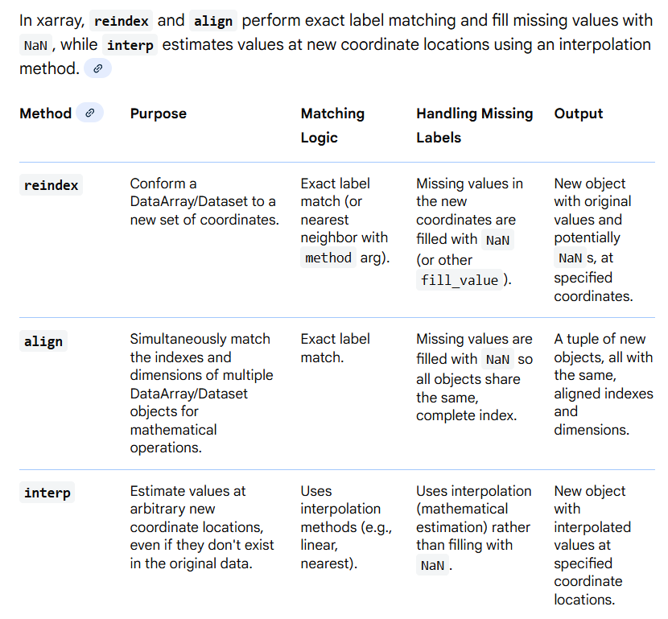

```python
malaysia = gpd.read_file('gadm41_MYS_shp/gadm41_MYS_1.shp')
east_malaysia_states = ["Labuan", "Sabah", "Sarawak"]
peninsular_malaysia = malaysia[~malaysia["NAME_1"].isin(east_malaysia_states)]

# Make sure its coordinate reference system matches
peninsular_malaysia = peninsular_malaysia.to_crs(epsg=4326)
peninsular_malaysia_buffered = peninsular_malaysia.buffer(0.01)

era5_land_data_clipped = era5_land_ds["toa_influx_hourly"].rio.write_crs("EPSG:4326")
era5_land_data_clipped = era5_land_data_clipped.rio.clip(peninsular_malaysia_buffered.geometry, peninsular_malaysia.crs)

era5_data_clipped = era5_ds["tisr"].rio.write_crs("EPSG:4326")
era5_data_clipped = era5_data_clipped.rio.clip(peninsular_malaysia_buffered.geometry, peninsular_malaysia.crs)
```

```python
era5_land_reindexed = era5_land_data_clipped.reindex(
    latitude= era5_data_clipped.latitude,
    longitude= era5_data_clipped.longitude,
    method='nearest',
    tolerance=0.1
)
```

```python
#Check if all the coords are the same
print(era5_land_reindexed["valid_time"].equals(era5_data_clipped["valid_time"]))
print(era5_land_reindexed["latitude"].equals(era5_data_clipped["latitude"]))
print(era5_land_reindexed["longitude"].equals(era5_data_clipped["longitude"]))
```

```
True
True
True
```

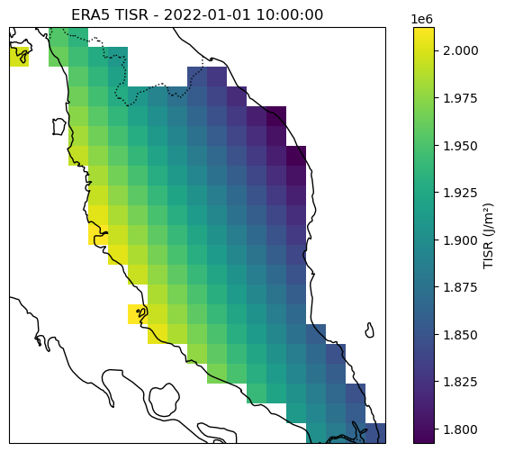

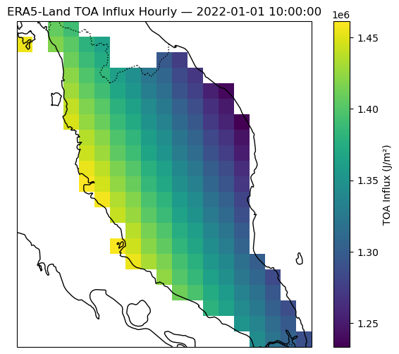

```python
#Before running the tests, I want to get a visual confirmation that I am computing it for the right dimensions/coordinates.

#Some grid cells might only be present in 1 dataset and not the other after reindexing.
#To ensure we compute the statistics of grid cells in both datasets, I used a mask.
valid_mask = (~np.isnan(era5_data_clipped).any(dim='valid_time')) & \
             (~np.isnan(era5_land_reindexed).any(dim='valid_time'))

x_valid = era5_land_reindexed.where(valid_mask)
y_valid = era5_data_clipped.where(valid_mask)

# Pick one time index (for example, the first one). Seems like the interpolation is not perfect, but we will just ignore for now.
time_idx = 10
time_val_2 = pd.to_datetime(x_valid.valid_time.values[time_idx]).strftime("%Y-%m-%d %H:%M:%S")
time_val_1 = pd.to_datetime(y_valid.valid_time.values[time_idx]).strftime("%Y-%m-%d %H:%M:%S")


fig, ax = plt.subplots(figsize=(8, 6), subplot_kw={'projection': ccrs.PlateCarree()})
y_valid.isel(valid_time=time_idx).plot(
    x="longitude",
    y="latitude",
    transform=ccrs.PlateCarree(),
    ax=ax,
    cbar_kwargs={"label": "TISR (J/m²)"}
)
ax.set_title(f"ERA5 TISR - {time_val_2}")
ax.coastlines(resolution="10m")
ax.add_feature(cfeature.BORDERS, linestyle=":")
plt.show()


fig, ax = plt.subplots(figsize=(8, 6), subplot_kw={'projection': ccrs.PlateCarree()})
x_valid.isel(valid_time=time_idx).plot(
    x="longitude",
    y="latitude",
    transform=ccrs.PlateCarree(),
    ax=ax,
    cbar_kwargs={"label": "TOA Influx (J/m²)"}
)
ax.set_title(f"ERA5-Land TOA Influx Hourly — {time_val_1}")
ax.coastlines(resolution="10m")
ax.add_feature(cfeature.BORDERS, linestyle=":")
plt.show()
```

The resulting plots above is what I intend to calculate the statisical values for.

We will flatten the full lat/long/time arrays into a flat array, to produce a global metric across the entire dataset.

```python
# 1. Create the mask to compare only matching lat/long values
valid_mask = (~np.isnan(era5_data_clipped).any(dim='valid_time')) & \
             (~np.isnan(era5_land_reindexed).any(dim='valid_time'))

# 2. Apply mask to select only valid lat/lon points (keeps all times)
x_valid = era5_data_clipped.where(valid_mask)
y_valid = era5_land_reindexed.where(valid_mask)

# 3. Flatten arrays over all dimensions for metric calculation
x_flat = x_valid.values.flatten()
y_flat = y_valid.values.flatten()

# 4. Remove any remaining NaNs
mask = ~np.isnan(x_flat) & ~np.isnan(y_flat)
x_flat = x_flat[mask]
y_flat = y_flat[mask]

# 5. Compute metrics
def rmse(a, b):
    return np.sqrt(np.mean((a - b)**2))

def mbe(a, b):
    return np.mean(a - b)

def mae(a, b):
    return np.mean(np.abs(a - b))

def nrmse(a, b):
    return rmse(a, b) / (np.max(a) - np.min(a))

def nmae(a, b):
    return mae(a, b) / (np.max(a) - np.min(a))

def correlation(a, b):
    return np.corrcoef(a, b)[0, 1]

print("RMSE:", rmse(x_flat, y_flat))
print("MBE:", mbe(x_flat, y_flat))
print("MAE:", mae(x_flat, y_flat))
print("NRMSE:", nrmse(x_flat, y_flat))
print("NMAE:", nmae(x_flat, y_flat))
print("R:", correlation(x_flat, y_flat))
```

```
RMSE: 302553.81473876664
MBE: 3144.265368234472
MAE: 195104.71146356905
NRMSE: 0.061466692956614596
NMAE: 0.03963738287112555
R: 0.9859437132820416
```

- **The RMSE and MAE values are small relative to the typical daily TOA peak (~4–5×10⁶ J/m²).**  
  This indicates that absolute deviations remain modest.
- **MBE is close to zero (relative to the magnitude of the data)**. The peak TOA value is 4 to 5 million J/m² while this is around 3144 J/m² which is less than 1%. This means the method does not introduce any meaningful systematic bias—no consistent “overprediction” or “underprediction.”
- **NRMSE (~6%) and NMAE (~4%)** are well within the acceptable range for climate-physics variables, especially when comparing datasets with slightly different handling of solar accumulation windows.
- **Correlation (R ≈ 0.986)** is extremely high, confirming that the temporal patterns—sunrise timing, peak irradiance, seasonal behaviour—are captured almost perfectly.  
  This is expected, since TOA geometry is deterministic, but it provides strong validation that the implementation is correct.

### Unit Testing 1

Test each function and check the resultant value to see if it matches logical/physical values. This is already implemented in the unit tests files.

Implemented in the individual function files. See the test under the `tests` folder. To run the tests, you can use `pytest tests/` or `pytest tests/ -vv` for verbose printing in the terminal.

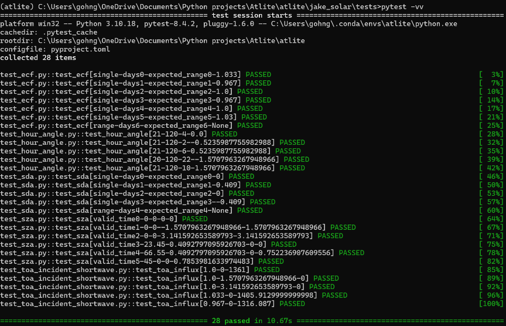

### Unit Testing 2

Select a particular latitude, longitude and time and see if it matches online resources:

1. https://www.pveducation.org/pvcdrom/properties-of-sunlight/solar-time.
2. http://www.geoastro.de/astro/suncalc/index.htm

These websites provide calculators so you can input the parameters (such as date, latitude, longitude, time, etc) to give an output for the various parameters.

The values printed here matches the website which gives validity to our functions

```python
#Check 4. TOA influx
ecf = 1.031
sza = 0.41539545
x = xr.Dataset(
        data_vars={
            "ECF": ((), ecf),  # scalar
            "SZA": ((), sza),  # radians
        }
    )

result = tf.calc_toa_incident_shortwave(x)
print(result)
```

```
<xarray.Dataset> Size: 24B
Dimensions:     ()
Data variables:
    ECF         float64 8B 1.031
    SZA         float64 8B 0.4154
    toa_influx  float64 8B 1.284e+03
```

```python
#Check 4. SZA
time = pd.to_datetime(f"2020-01-21 4:00:00")
sda = -0.3515
latitude = np.deg2rad(3.5)
hour_angle = -0.04911239
x = xr.Dataset(
        data_vars={
            "SDA": (("valid_time"), [sda]),             #already radians
            "hour_angle": (("longitude", "valid_time"), [[hour_angle]]) #already radians
        },
        coords={
            "latitude": ("latitude", [latitude]),  # already radians
            "longitude": ("longitude", [0]),       # dummy longitude
            "valid_time": ("valid_time", [time])
        }
    )
result = tf.calc_solar_zenith_angle(x)
print(result)
```

```
<xarray.DataArray 'SZA' (latitude: 1, valid_time: 1, longitude: 1)> Size: 8B
array([[[0.41539545]]])
Coordinates:
  * latitude    (latitude) float64 8B 0.06109
  * longitude   (longitude) int64 8B 0
  * valid_time  (valid_time) datetime64[ns] 8B 2020-01-21T04:00:00
<xarray.Dataset> Size: 48B
Dimensions:     (valid_time: 1, longitude: 1, latitude: 1)
Coordinates:
  * latitude    (latitude) float64 8B 0.06109
  * longitude   (longitude) int64 8B 0
  * valid_time  (valid_time) datetime64[ns] 8B 2020-01-21T04:00:00
Data variables:
    SDA         (valid_time) float64 8B -0.3515
    hour_angle  (longitude, valid_time) float64 8B -0.04911
    SZA         (latitude, valid_time, longitude) float64 8B 0.4154
```

```python
#Check 4. SDA
day = pd.to_datetime(f"2020-01-21 4:00:00").day_of_year
x = xr.Dataset(
    xr.Dataset({"day_of_year": ("valid_time", [day])})
)
result = tf.calc_solar_declination_angle(x)
print(x)
```

```
<xarray.Dataset> Size: 24B
Dimensions:      (valid_time: 1)
Coordinates:
  * valid_time   (valid_time) int64 8B 0
Data variables:
    day_of_year  (valid_time) int64 8B 21
    SDA          (valid_time) float64 8B -0.3515
```

```python
#Check 4. ECF
day = pd.to_datetime(f"2020-01-21 4:00:00").day_of_year
x = xr.Dataset(
    xr.Dataset({"day_of_year": ("valid_time", [day])})
)
result = tf.calc_eccentricty_correlation_factor(x)
print(x)
```

```
<xarray.Dataset> Size: 24B
Dimensions:      (valid_time: 1)
Coordinates:
  * valid_time   (valid_time) int64 8B 0
Data variables:
    day_of_year  (valid_time) int64 8B 21
    ECF          (valid_time) float64 8B 1.031
```

```python
#Check 3.PV Education TC formula. Pass by manually checking each intermediate step from hour angle function
time = pd.to_datetime(f"2020-01-21 4:00:00")
x = xr.Dataset(
    data_vars={
        "ssrd": (("valid_time", "latitude", "longitude"), np.zeros((1, 1, 1)))
    },
    coords={
        "longitude": ("longitude", [120]),
        "valid_time": ("valid_time", [time]),
        "day_of_year": ("day_of_year", [time.dayofyear])
    }
)
result = tf.calc_hour_angle(x)
```

```
[120]
----------------------
<xarray.DataArray 'LT' (valid_time: 1)> Size: 8B
array([12.])
Coordinates:
  * valid_time  (valid_time) datetime64[ns] 8B 2020-01-21T04:00:00
----------------------
<xarray.DataArray 'B_param_rad' (valid_time: 1)> Size: 8B
array([-1.03285238])
Coordinates:
  * valid_time  (valid_time) datetime64[ns] 8B 2020-01-21T04:00:00
----------------------
<xarray.DataArray 'EOT' (valid_time: 1)> Size: 8B
array([-11.25573125])
Coordinates:
  * valid_time  (valid_time) datetime64[ns] 8B 2020-01-21T04:00:00
----------------------
<xarray.DataArray 'TC' (longitude: 1, valid_time: 1)> Size: 8B
array([[-11.25573125]])
Coordinates:
  * longitude   (longitude) int64 8B 120
  * valid_time  (valid_time) datetime64[ns] 8B 2020-01-21T04:00:00
----------------------
<xarray.DataArray 'LST' (valid_time: 1, longitude: 1)> Size: 8B
array([[11.81240448]])
Coordinates:
  * longitude   (longitude) int64 8B 120
  * valid_time  (valid_time) datetime64[ns] 8B 2020-01-21T04:00:00
----------------------
<xarray.DataArray 'hour_angle' (valid_time: 1, longitude: 1)> Size: 8B
array([[-0.04911239]])
Coordinates:
  * longitude   (longitude) int64 8B 120
  * valid_time  (valid_time) datetime64[ns] 8B 2020-01-21T04:00:00
```